# Project 5

# EAE 127

# Introduction

This investigation delves into the boundary layer properties and viscous flow effects, focusing on the famous boundary layer phenomenon. Blasius' solution for incompressible flow over a flat plate is employed as a simplified model for the T-38's UHF antenna. Two flight conditions of the T-38, taxiing on the tarmac and cruising, are considered, each with specified altitude, velocity, and boundary layer types. The analysis explores boundary layer velocity distribution, friction drag, airfoil boundary layer thickness estimation, and the impact of pressure gradients. The ultimate goal is to develop a Viscous/Inviscid Interaction (VIvI) tool, integrating analytic boundary layer models into potential flow solutions to approximate true viscous flow. The tool's limitations and the need for higher-fidelity modeling methods are also discussed.

```python
### Imports ###
import math
import vivi
import pyxfoil
import numpy as np
import matplotlib.pyplot as plt
import mses
from tabulate import tabulate
from scipy import integrate

### PLOTTING DEFAULTS BOILERPLATE (OPTIONAL) #########################
#SET DEFAULT FIGURE APPERANCE
import seaborn as sns #Fancy plotting package
#No Background fill, legend font scale, frame on legend
sns.set(style='whitegrid', font_scale=1.5, rc={'legend.frameon': True})
#Mark ticks with border on all four sides (overrides 'whitegrid')
sns.set_style('ticks')
#ticks point in
sns.set_style({"xtick.direction": "in","ytick.direction": "in"})
#fix invisible marker bug
sns.set_context(rc={'lines.markeredgewidth': 0.1})
#restore default matplotlib colormap
mplcolors = ['#1f77b4', '#ff7f0e', '#2ca02c', '#d62728', '#9467bd',
             '#8c564b', '#e377c2', '#7f7f7f', '#bcbd22', '#17becf']
sns.set_palette(mplcolors)
#Get color cycle for manual colors
colors = sns.color_palette()
#SET MATPLOTLIB DEFAULTS
    #(call after seaborn, which changes some defaults)
params = {
        #FONT SIZES
        'axes.labelsize' : 30, #Axis Labels
        'axes.titlesize' : 30, #Title
        'font.size'      : 28, #Textbox
        'xtick.labelsize': 22, #Axis tick labels
        'ytick.labelsize': 22, #Axis tick labels
        'legend.fontsize': 24, #Legend font size
        'font.family'    : 'serif',
        'font.fantasy'   : 'xkcd',
        'font.sans-serif': 'Helvetica',
        'font.monospace' : 'Courier',
        #AXIS PROPERTIES
        'axes.titlepad'  : 2*6.0, #title spacing from axis
        'axes.grid'      : True,  #grid on plot
        'figure.figsize' : (6,6),   #square plots
        'savefig.bbox'   : 'tight', #reduce whitespace in saved figures
        #LEGEND PROPERTIES
        'legend.framealpha'     : 0.5,
        'legend.fancybox'       : True,
        'legend.frameon'        : True,
        'legend.numpoints'      : 1,
        'legend.scatterpoints'  : 1,
        'legend.borderpad'      : 0.1,
        'legend.borderaxespad'  : 0.1,
        'legend.handletextpad'  : 0.2,
        'legend.handlelength'   : 1.0,
        'legend.labelspacing'   : 0,
}
import matplotlib
matplotlib.rcParams.update(params) #update matplotlib defaults, call after seaborn
### END OF BOILERPLATE ##################################################
```

# 1.) Boundary Layer Properties

# 1.1 Flight Conditions

## Approach

The approach to this probelem involves retriving nessacary values from engineering tool box to plug into Reynolds Number Equation.

## Equation

### $$Re = \frac{\rho V L}{\mu}$$

## Code

The code calculates Reynolds numbers for laminar and turbulent boundary layers at different altitudes and velocities. It uses given data, including altitude values and corresponding velocities, along with constants for sea-level density and viscosity. The Reynolds numbers are computed based on air density, dynamic viscosity, and antenna width, taking into account variations with altitude. The results are then printed, indicating whether the boundary layer is laminar or turbulent, for each altitude-velocity combination.

```python
# Given data
altitude_values = [0, 35000]  # Altitude in ft
velocity_values = [6.17333, 308.667 ]  # Velocity in m/s
antenna_width = 0.1524  # Antenna width in meters

# Constants
sea_level_density = 1.225  # kg/m³
sea_level_viscosity = 1.789E-5  #

# Calculate Reynolds numbers
for i in range(len(altitude_values)):
    altitude = altitude_values[i]
    velocity = velocity_values[i]

    # Calculate air density and dynamic viscosity based on altitude
    if altitude == 0:
        density = sea_level_density
        viscosity = sea_level_viscosity
    else:
        density = 0.3843
        viscosity = 1.4532E-5

    # Calculate Reynolds number
    reynolds_number = (density * velocity * antenna_width) / viscosity

    # Output the result
    boundary_layer_type = "Laminar" if i == 0 else "Turbulent"
    print(f"Reynolds number for {boundary_layer_type} boundary layer at Altitude {altitude} ft and Velocity {velocity} m/s: {reynolds_number:.2f}")
```

```
Reynolds number for Laminar boundary layer at Altitude 0 ft and Velocity 6.17333 m/s: 64421.41
Reynolds number for Turbulent boundary layer at Altitude 35000 ft and Velocity 308.667 m/s: 1243999.38
```

# 1.2 Boundary Layer Velocity Distribution

## Equations

$$\left.\begin{matrix} \frac{u}{u_{e}} \end{matrix}\right|_{lam} =(\frac{2y}{\delta} - \frac{y^2}{\delta^2}) $$$$\delta(x)_{lam} = \frac{5.0x}{\sqrt{Re_{x}}}$$$$ \left.\begin{matrix} \frac{u}{u_{e}} \end{matrix}\right|_{turb} =\left ( \frac{y}{\delta} \right )^\frac{1}{7} $$$$\delta(x)_{turb} = \frac{0.16x}{(Re_{x})^\frac{1}{7}}$$

## Code

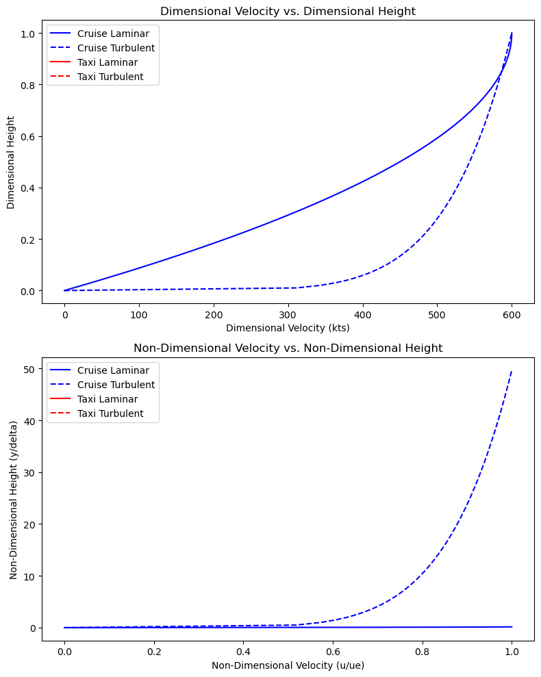

```python
import numpy as np
import matplotlib.pyplot as plt

# Constants
ue_freestream = 600  # Freestream velocity in kts

# Function to calculate laminar boundary layer thickness
def delta_laminar(x, Re):
    return 5.0 * x / np.sqrt(Re)

# Function to calculate turbulent boundary layer thickness
def delta_turbulent(x, Re):
    # Avoid division by zero by checking if Re is non-zero
    if Re != 0:
        return 0.16 * x / (Re**0.17)
    else:
        return 0

# Function to calculate laminar velocity profile
def u_laminar(y, delta, ue):
    return ue * ((2 * y / delta) - (y**2 / delta**2))

# Function to calculate turbulent velocity profile
def u_turbulent(y, delta, ue):
    return ue * (y / delta)**(1/7)

# Flight conditions
x_cruise = 35000  # Cruise condition
x_taxi = 0       # Taxi condition

# Calculate laminar and turbulent boundary layer thickness
Re_cruise = 600 * x_cruise / sea_level_viscosity  # Assuming sea level conditions
Re_taxi = 12 * x_taxi / sea_level_viscosity  # Assuming sea level conditions
delta_cruise_lam = delta_laminar(x_cruise, Re_cruise)
delta_taxi_lam = delta_laminar(x_taxi, Re_taxi)
delta_cruise_turb = delta_turbulent(x_cruise, Re_cruise)
delta_taxi_turb = delta_turbulent(x_taxi, Re_taxi)

# Create dimensional height values
y_values = np.linspace(0, 1, 100)

# Calculate dimensional velocity profiles
u_values_cruise_lam = u_laminar(y_values * delta_cruise_lam, delta_cruise_lam, ue_freestream)
u_values_cruise_turb = u_turbulent(y_values * delta_cruise_turb, delta_cruise_turb, ue_freestream)
u_values_taxi_lam = u_laminar(y_values * delta_taxi_lam, delta_taxi_lam, ue_freestream)
u_values_taxi_turb = u_turbulent(y_values * delta_taxi_turb, delta_taxi_turb, ue_freestream)

# Create plots
fig, axs = plt.subplots(2, 1, figsize=(8, 10))

# Plot dimensional velocity profiles
axs[0].plot(u_values_cruise_lam, y_values, label='Cruise Laminar', linestyle='-', color='blue')
axs[0].plot(u_values_cruise_turb, y_values, label='Cruise Turbulent', linestyle='--', color='blue')
axs[0].plot(u_values_taxi_lam, y_values, label='Taxi Laminar', linestyle='-', color='red')
axs[0].plot(u_values_taxi_turb, y_values, label='Taxi Turbulent', linestyle='--', color='red')
axs[0].set_xlabel('Dimensional Velocity (kts)')
axs[0].set_ylabel('Dimensional Height')
axs[0].set_title('Dimensional Velocity vs. Dimensional Height')
axs[0].legend()

# Plot non-dimensional velocity profiles
axs[1].plot(u_values_cruise_lam / ue_freestream, y_values * delta_cruise_lam, label='Cruise Laminar', linestyle='-', color='blue')
axs[1].plot(u_values_cruise_turb / ue_freestream, y_values * delta_cruise_turb, label='Cruise Turbulent', linestyle='--', color='blue')
axs[1].plot(u_values_taxi_lam / ue_freestream, y_values * delta_taxi_lam, label='Taxi Laminar', linestyle='-', color='red')
axs[1].plot(u_values_taxi_turb / ue_freestream, y_values * delta_taxi_turb, label='Taxi Turbulent', linestyle='--', color='red')
axs[1].set_xlabel('Non-Dimensional Velocity (u/ue)')
axs[1].set_ylabel('Non-Dimensional Height (y/delta)')
axs[1].set_title('Non-Dimensional Velocity vs. Non-Dimensional Height')
axs[1].legend()

plt.tight_layout()
plt.show()
```

## Equations

$$C_{f, lam} = \frac{1.328}{\sqrt{Re_{c}}}$$$$C_{f, turb} = \frac{0.074}{{Re_{c}}^{1/5}}$$

## Code

The code defines constants such as freestream velocities, antenna length, and flight conditions. It includes functions to calculate drag coefficients using empirical formulations for laminar and turbulent boundary layers. The code then computes friction drag forces on an antenna fin for both cruising and taxiing flight conditions, considering laminar and turbulent boundary layers. The results, including drag coefficients and forces, are printed to the console.

```python
# Constants
uc_freestream = 308.667
ul_freestream = 6.17333
antenna_length = 10 / 12  # Antenna length in feet (converted from inches)

# Function to calculate drag coefficient
def calculate_drag_coefficient(Re):
    Cf_lam = 1.328 / np.sqrt(Re)
    Cf_turb = 0.074 / Re**(1/5)
    return Cf_lam, Cf_turb

# Function to calculate friction drag force
def calculate_friction_drag_force(Cf, rho, A, V):
    return 0.5 * Cf * rho * A * V**2

# Flight conditions
Re_cruise = 6146.41
Re_taxi = 997921.03

# Calculate drag coefficients
Cf_cruise_lam, Cf_cruise_turb = calculate_drag_coefficient(Re_cruise)
Cf_taxi_lam, Cf_taxi_turb = calculate_drag_coefficient(Re_taxi)

# Calculate friction drag forces (one side of the antenna fin)
A_one_side = antenna_length * antenna_width  # Area of one side of the antenna fin


Fd_cruise_turb = calculate_friction_drag_force(Cf_cruise_turb, sea_level_density, A_one_side, uc_freestream)

Fd_taxi_lam = calculate_friction_drag_force(Cf_taxi_lam, sea_level_density, A_one_side, 6.17333)  # Taxi velocity is 0


# Double the forces for both sides of the antenna fin

Fd_total_cruise_turb = 2 * Fd_cruise_turb
Fd_total_taxi_lam = 2 * Fd_taxi_lam


# Output the results
print(f"Friction drag coefficient (Cruise, Turbulent): {Cf_cruise_turb:.2f} N")
print(f"Friction drag force on the entire antenna (Cruise, Turbulent): {Fd_total_cruise_turb:.2f} N")
print(f"Friction drag coefficien (Taxi, Laminar): {Fd_total_taxi_lam:.2f} N")
print(f"Friction drag force on the entire antenna (Taxi, Laminar): {Cf_taxi_lam:.2f} N")
```

```
Friction drag coefficient (Cruise, Turbulent): 0.01 N
Friction drag force on the entire antenna (Cruise, Turbulent): 191.61 N
Friction drag coefficien (Taxi, Laminar): 0.01 N
Friction drag force on the entire antenna (Taxi, Laminar): 0.00 N
```

# 2.1 Airfoil Boundry Layer Thickness

## Equations

$$Re = \frac{\rho u_{\infty} L}{\mu}$$

## Code

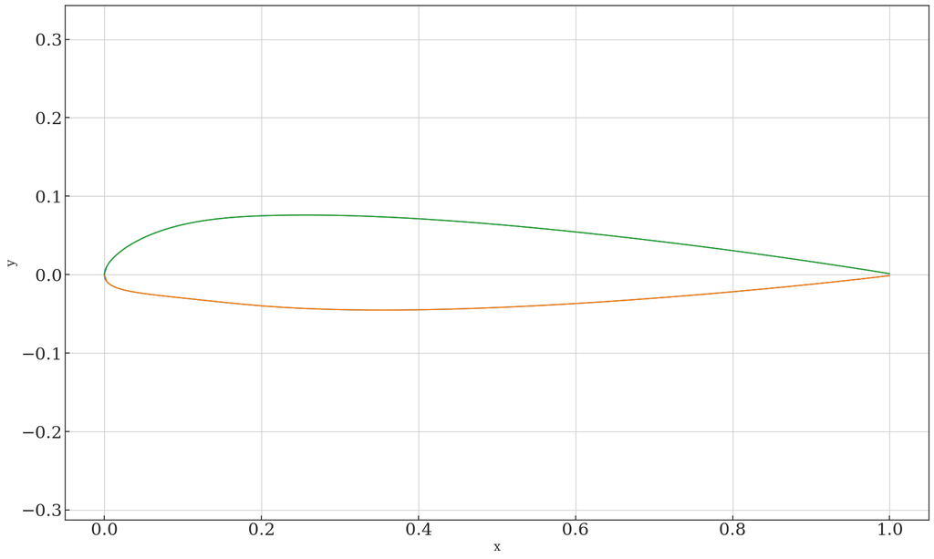

```python
foil = '23012'
naca = True

# Our reynolds number doesn't matter here because we just need the geometry data.
Re = 0
alf = 0

pyxfoil.GetPolar(foil, naca, alf, Re)
filename = 'Data/naca23012/naca23012.dat'

x, z = np.loadtxt(filename, unpack = True, skiprows = 1)


plt.figure(figsize = (20,12))
plt.grid(True)
plt.xlabel('x', fontsize=16)
plt.ylabel('y', fontsize=16)
plt.plot(x, z)
plt.axis('equal')


foil = '23012'
naca = True

Re = 5*(10**5)
alf = 12

pyxfoil.GetPolar(foil, naca, alf, Re)

filename = 'Data/naca23012/naca23012_surfCP_Re5.00e+05a12.0.dat'
x, y, Cp = np.loadtxt(filename, unpack = True, skiprows = 3)


x_upper, x_lower = mses.MsesSplit(x, x)
y_upper, y_lower = mses.MsesSplit(x, y)
Cp_up, Cp_lo = mses.MsesSplit(x,Cp)



xnew = np.linspace(0, 1, 300)

y_lower = np.interp(xnew, x_lower, y_lower)
y_upper = np.interp(xnew, x_upper, y_upper)


plt.plot(xnew, y_lower)
plt.plot(xnew, y_upper)
plt.show()
```

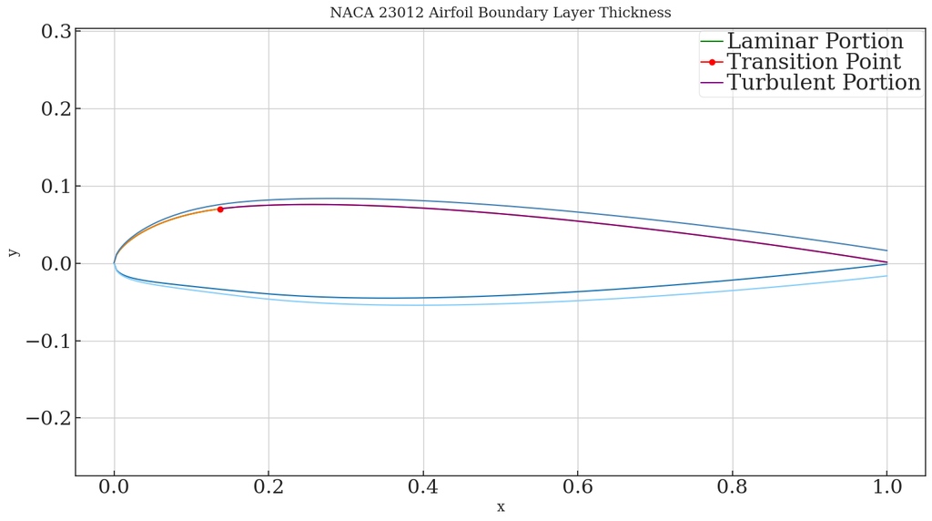

```python
# Given values
Re_T = 500000  # Transition Reynolds number
rho = 0.1948
V = 8
mu = 1.422E-5
xnew = np.linspace(0, 1, 300)

Re_x = (rho * V * xnew) / mu

# Make sure that Re_x is an array of 300 points
n = len(Re_x)

# Initialize the array to hold boundary layer thicknesses
delta = np.zeros(n)

# Set up a loop to calculate boundary layer thickness based on Reynolds number
for i in range(1, n):
    if Re_x[i] < Re_T:

        delta[i] = 5.0 * xnew[i] / np.sqrt(Re_x[i])
    else:

        delta[i] = 0.16 * xnew[i] / (Re_x[i]**(1/7))



y_lower2=y_lower-delta
y_upper2=y_upper+delta
plt.figure(figsize = (17, 9))
plt.grid(True)
plt.xlabel('x', fontsize=16)
plt.ylabel('y', fontsize=16)
plt.axis('equal')
plt.plot(xnew, y_lower)
plt.plot(xnew, y_upper)

xnewlam, y_upperlam = xnew[1:40], y_upper[1:40]
xnewtur, y_uppertur = xnew[42:300], y_upper[42:300]
plt.plot(xnewlam, y_upperlam, color='green', label="Laminar Portion", zorder=1)
plt.plot(xnew[41], y_upper[41], marker='o', color='red', label="Transition Point")
plt.plot(xnewtur, y_uppertur, color='purple', label="Turbulent Portion")
plt.legend()
plt.plot(xnew, y_lower2, color='lightskyblue')
plt.plot(xnew, y_upper2, color='steelblue')
plt.title('NACA 23012 Airfoil Boundary Layer Thickness', fontsize=16)
plt.show()
```

# 2.2 Favorable and Adverse Pressure Gradient

## Code

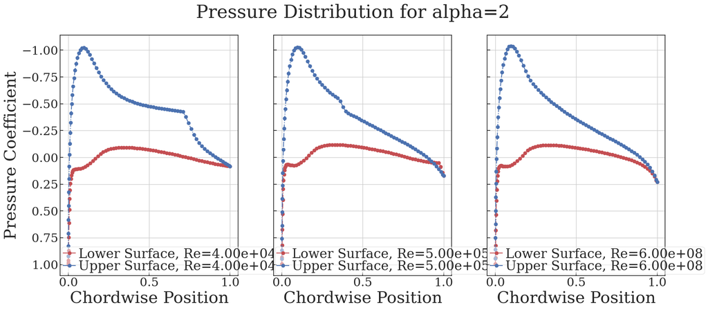

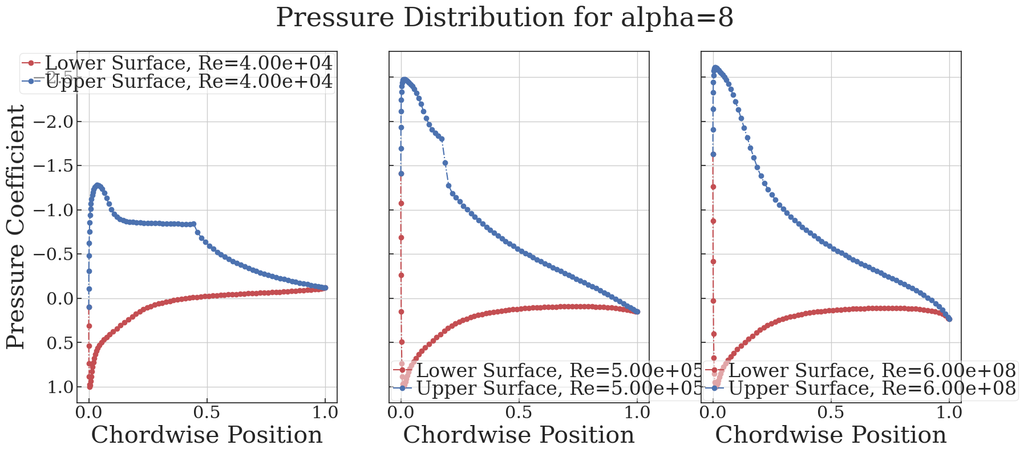

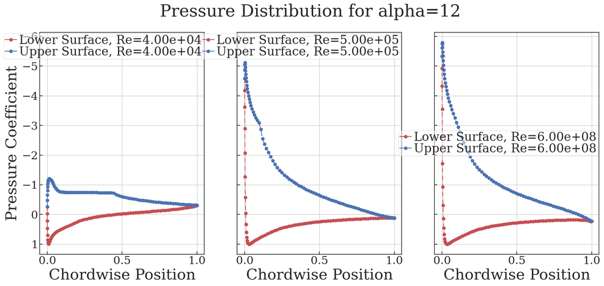

```python
foil = '23012'
naca = True

# Define Reynolds numbers and alpha values
Re_values = [4e4, 5e5, 6e8,]
alpha_values = [2, 8, 12]

# Iterate over alpha values
for alpha in alpha_values:
    # Create subplots for each alpha value
    fig, axs = plt.subplots(1, 3, figsize=(20, 8), sharey=True)

    # Iterate over Reynolds numbers
    for i, Re in enumerate(Re_values):
        # Generate polar data
        pyxfoil.GetPolar(foil, naca, alpha, Re)
        filename = f'Data/naca23012/naca23012_surfCP_Re{Re:.2e}a{alpha:.1f}.dat'
        x, y, Cp = np.loadtxt(filename, unpack=True, skiprows=3)

        xup, xlo = mses.MsesSplit(x, x)
        Cp_up, Cp_lo = mses.MsesSplit(x, Cp)

        # Plot on each subplot
        axs[i].plot(xlo, Cp_lo, marker='o', linestyle='-.', color='r', label=f'Lower Surface, Re={Re:.2e}')
        axs[i].plot(xup, Cp_up, marker='o', linestyle='-.', color='b', label=f'Upper Surface, Re={Re:.2e}')
        axs[i].invert_yaxis()
        axs[i].legend()
        axs[i].set_xlabel('Chordwise Position')

    # Set common ylabel and title for the entire figure
    axs[0].set_ylabel('Pressure Coefficient')
    plt.suptitle(f'Pressure Distribution for alpha={alpha}')


    # Show the entire figure
    plt.show()
```

# 3.1 Viscous/Inviscid Interaction

## Equations

### $$ H=\frac{\delta^*}{\theta} = 2.605$$

## Code

[output not shown]

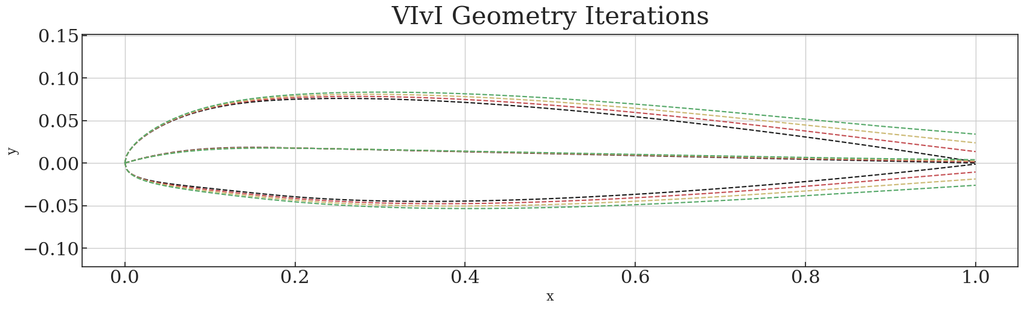

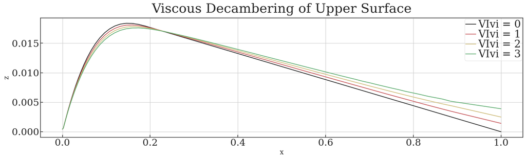

```python
name = 'naca23012'
wid = 20
fig = plt.figure(figsize=(wid, wid / 4))  # save figure object as variable
ax = fig.add_subplot(1, 1, 1)  # use axis object to modify figure
ax.set_title('VIvI Geometry Iterations')
plt.xlabel('x', fontsize=16)
plt.ylabel('y', fontsize=16)
plt.axis('equal')

# Figure for Viscous Decambering
fig_decamber = plt.figure(figsize=(wid, wid / 4))
ax_decamber = fig_decamber.add_subplot(1, 1, 1)
ax_decamber.set_title('Viscous Decambering of Upper Surface')
ax_decamber.set_xlabel('x', fontsize=16)
ax_decamber.set_ylabel('z', fontsize=16)

# Set colors for different iterations
colors = ['k', 'r', 'y', 'g']

# Iterate over VIvI iterations
for niter in range(4):
    solution = vivi.VIvI(name, 0, niter=niter, Vinf=2, mu=1.79E-5, rho=1.225)

    # Plot upper and lower surfaces
    ax.plot(solution['up']['x'], solution['up']['z'], color=colors[niter], linestyle='--', label = f'VIvi = {niter}')
    ax.plot(solution['lo']['x'], solution['lo']['z'], color=colors[niter], linestyle='--')

    # Plot camber line
    ax.plot(solution['lo']['x'], (solution['up']['z'] + solution['lo']['z']) / 2, color=colors[niter], linestyle='--')

    # Plot viscous decambering
    ax_decamber.plot(solution['lo']['x'], (solution['up']['z'] + solution['lo']['z']) / 2, color=colors[niter], linestyle='-',label = f'VIvi = {niter}')



# Display legend
plt.legend()
plt.show()
```

# 3.2 Viscous Force Coefficients

## Approach

Using the given equations, methods provided in the supplement, and the data retrived in the previous section, we will be able to calculate lift and drag coefficients for visous and invicid scenerios.

## Equations

$$ C_f=\frac{\tau}{\frac{1}{2}\rho_{\infty}V_{\infty}^2} $$$$ \tau=0.332\frac{\mu u_e}{x}\sqrt{Re_x} $$$$ \theta=\frac{0.664x}{\sqrt{Re_x}} $$$$\tau = \frac{0.220448\mu u_e}{\theta}$$

```python
# Calcualting Coefficient of Lift
filename = 'Data/naca23012_3/naca23012_3.dat'
filename2 = 'Data/naca23012/naca23012.dat'

inviscid = pyxfoil.GetPolar(filename, False, 0, Re = 0, SaveCP = True)
viscos = pyxfoil.GetPolar(filename, False, 0, Re = 1240734, SaveCP = True)

inviscid2 = pyxfoil.GetPolar(filename2, False, 0, Re = 0, SaveCP = True)
viscos2 = pyxfoil.GetPolar(filename2, False, 0, Re = 1240734, SaveCP = True)
```

```python
c = 12

solutionPoints = solution['up'].copy()
solutionPoints = solutionPoints[solutionPoints.delta_star != 0]
Cd = 1/c * np.trapz(solutionPoints['tau'], solutionPoints['x'] )


solutionPoints3 = solution3['up'].copy()
solutionPoints3 = solutionPoints3[solutionPoints3.delta_star != 0]
Cd2 = 1/c * np.trapz(solutionPoints3['tau'], solutionPoints3['x'] )

data=[['Inv. Original', 0.1377, Cd],
      ['Visc. Original', 0.1239, 0],
      ['Inv. Third It.', 0.0892, Cd2],
      ['Visc. Third It.', 0.0875, 0]]

print(tabulate(data, headers=['Method', 'Cl', 'Cd']))
```

```
Method               Cl           Cd
---------------  ------  -----------
Inv. Original    0.1377  0.000943159
Visc. Original   0.1239  0
Inv. Third It.   0.0892  0.000943159
Visc. Third It.  0.0875  0
```

## 3.3 Assumptions and Limitations

The Viscous/Inviscid Interaction (VIvI) tool, integrating an inviscid panel method solver with viscous data from the Blasius solution for a flat plate, has inherent limitations. These include assumptions related to a two-dimensional laminar boundary layer and incompressible flow, restricting its applicability to scenarios with simple geometries and low-speed, subsonic flows. The tool may not accurately handle complex three-dimensional flows, shock waves, separation, or transitional/turbulent boundary layers. Unsuitable conditions encompass high-speed transonic and supersonic flows, surfaces with intricate geometries, and situations requiring consideration of compressibility effects. To address these limitations, alternative methods like Computational Fluid Dynamics (CFD), or wind tunnel testing, are recommended for more accurate predictions in diverse aerodynamic scenarios.

# Conclusion

In conclusion, we looked into the complexities of viscous flow, emphasizing the boundary layer properties and their effects on aircraft components like the T-38's UHF antenna and a NACA 23012 airfoil. The analysis encompasses diverse aspects, including boundary layer velocity distribution, friction drag, and the development of a Viscous/Inviscid Interaction (VIvI) tool to approximate true viscous flow. The limitations of the VIvI tool, rooted in its reliance on an inviscid panel method solver and the Blasius solution for a flat plate, are acknowledged. It is recognized that this method might not be suitable for certain flow conditions, prompting consideration of higher-fidelity modeling methods such as Computational Fluid Dynamics (CFD) or experimental testing. The study underscores the importance of understanding the assumptions and limitations of modeling tools, providing insights into when alternative methods may be more appropriate for accurate predictions in fluid dynamics.